# Questions for Results

Zachary Rowson

6/9/2022

## Introduction

In this document I will identify and answer questions that I believe should be addressed in the results section of the paper.

```r
load("~/Desktop/Stephanie Projects/DNT60 Analysis/pipelining/raw data/Padilla_DNT60_pmr0_egid.Rdata")
load("~/Desktop/Stephanie Projects/DNT60 Analysis/pipelining/results/Padilla_DNT60_tcpl_out.Rdata")
load("~/Desktop/Stephanie Projects/DNT60 Analysis/results analysis/data/refer_chem.Rdata")
load("~/Desktop/Stephanie Projects/DNT60 Analysis/pipelining/pipelined data/Padilla_DNT60_tcplfits.rda")
load("~/Desktop/Stephanie Projects/DNT60 Analysis/pipelining/pipelined data/Padilla_DNT60_rows_n.rda")
tcpl_out.dt <- as.data.table(DNT60_tcpl_out)

# Remove AUC endpoints from datasets
AUC <- c("AUC_L","AUC_D","AUC_T")
tcpl_out.dt <- tcpl_out.dt[!endp%in%AUC]
refer_chem <- refer_chem[!aenm%in%AUC]
```

## Discussion of the Activity in Endpoints and Chemicals

### How much activity was observed

Number of chemicals active in at least one endpoint and their chemical names.

```r
chemicals <- tcpl_out.dt[, unique(name)]
actives <- tcpl_out.dt[hitcall > 0.8, unique(name)]
print(paste("number active:", length(actives)))
```

```
## [1] "number active: 22"
```

```r
actives
```

```
##  [1] "5,5-Diphenylhydantoin"
##  [2] "Chlorpyrifos (ethyl)"
##  [3] "D-sorbitol"
##  [4] "Tebuconazole"
##  [5] "5-Fluorouracil"
##  [6] "Polybrominated diphenyl ether (PBDE)-47"
##  [7] "6-Aminonicotinamide"
##  [8] "Bisphenol A (BPA)"
##  [9] "Acrylamide"
## [10] "Phenobarbital"
## [11] "Fluoxetine"
## [12] "Amphetamine"
## [13] "Paraquat"
## [14] "Bis(tributyltin) Oxide"
## [15] "Cocaine base"
## [16] "Diethylstilbesterol"
## [17] "Dieldrin"
## [18] "Diazepam"
## [19] "Heptachlor"
## [20] "Heptachlor epoxide"
## [21] "Loperamide"
## [22] "Triethyltin"
```

Percent of test chemicals declared active.

```r
( length(actives) / length(chemicals) ) * 100
```

```
## [1] 36.06557
```

Chemicals that were “high-confidence” negatives (I don’t know what the most appropriate terminology will be, check *Martin et al. 2022*) were negative.

Number of chemical-endpoint pairs active and percent active as a proportion of all tested.

```r
active_pairs <- tcpl_out.dt[hitcall > 0.8, .N]
total_pairs <- tcpl_out.dt[, .N]
perc_pairs_active <- (active_pairs / total_pairs) * 100
print(paste("Number of pairs active:", active_pairs))
```

```
## [1] "Number of pairs active: 57"
```

```r
print(paste("Percent of pairs active:", round(perc_pairs_active,1)))
```

```
## [1] "Percent of pairs active: 7.2"
```

### How many endpoints were hits for chemicals

```r
tcpl_out.dt[hitcall > 0.8, .N, by = name]
```

```
##                                        name N
##  1:                   5,5-Diphenylhydantoin 2
##  2:                    Chlorpyrifos (ethyl) 4
##  3:                              D-sorbitol 3
##  4:                            Tebuconazole 3
##  5:                          5-Fluorouracil 2
##  6: Polybrominated diphenyl ether (PBDE)-47 3
##  7:                     6-Aminonicotinamide 4
##  8:                       Bisphenol A (BPA) 2
##  9:                              Acrylamide 2
## 10:                           Phenobarbital 1
## 11:                              Fluoxetine 5
## 12:                             Amphetamine 3
## 13:                                Paraquat 5
## 14:                  Bis(tributyltin) Oxide 1
## 15:                            Cocaine base 2
## 16:                     Diethylstilbesterol 2
## 17:                                Dieldrin 1
## 18:                                Diazepam 3
## 19:                              Heptachlor 3
## 20:                      Heptachlor epoxide 1
## 21:                              Loperamide 4
## 22:                             Triethyltin 1
##                                        name N
```

Which chemical was active in the most endpoints?

```r
tcpl_out.dt[hitcall > 0.8, .N, by = name][N==max(N), name]
```

```
## [1] "Fluoxetine" "Paraquat"
```

### What chemicals induce the strongest response in endpoints

```r
pot_refer_chem <- refer_chem[refer_chem[, .(rowi = .I[abs(rval)==max(abs(rval))]), by=.(aenm)][, rowi]]
pot_refer_chem
```

```
##          aenm  conc      rval                                    cpid outlier
##  1:    avgS_L     4 -6.262577                              Fluoxetine    TRUE
##  2:     hbt_L     4 -5.609335                              Fluoxetine    TRUE
##  3:    strtlA 0.012 -4.348852                             Triethyltin    TRUE
##  4: strtlAavg    40  4.730165                                Paraquat    TRUE
##  5:    strtlF    40  4.468539                              Loperamide    TRUE
##  6:    avgJ_D     4  2.991138 Polybrominated diphenyl ether (PBDE)-47    TRUE
##  7:     hbt_D     4 -4.791963                                Paraquat    TRUE
##  8:    avgA_L    40 -6.267515                               Valproate    TRUE
##  9:    avgJ_L   1.2  4.532914                     6-Aminonicotinamide    TRUE
## 10:    avgS_D     4 -7.713836 Polybrominated diphenyl ether (PBDE)-47    TRUE
## 11:    avgA_D   1.2  4.334867                    Chlorpyrifos (ethyl)    TRUE
## 12:    avgS_T    40 -6.679837                     6-Aminonicotinamide    TRUE
## 13:     AUC_r    40  5.241836                              Loperamide    TRUE
##     direction
##  1:      down
##  2:      down
##  3:      down
##  4:        up
##  5:        up
##  6:        up
##  7:      down
##  8:      down
##  9:        up
## 10:      down
## 11:        up
## 12:      down
## 13:        up
```

### What does clustering of chemicals reveal about endpoints

```r
ac <- c("AUC_L","avgS_L", "avgA_L", "avgJ_L","hbt_L",
        "strtlA","strtlAavg", "strtlF",
        "AUC_D", "avgS_D","avgA_D", "avgJ_D", "hbt_D",
        "AUC_T","avgS_T","AUC_r")

## Gather BMC's
bmd <- lapply(tcplfits_n, function(chm) unlist(lapply(chm, function(fit) {
  hitcall <- fit[["summary"]]$hitcall
  bmd <- fit[["summary"]]$bmd
  if (!(hitcall>0.8 & !is.na(bmd) & bmd != 0)) {
    bmd <- 10000
  }
  bmd
})))
bmd <- do.call("rbind", bmd)
bmd <- log10(bmd[, ac])
bmd <- bmd[,-c(1,9,14)]

# Identify active chemicals
actives <- rownames(bmd)[apply(bmd, 1, function(row) any(row < 4))]

# Isolate data of interest
to.fit <- bmd

# PBDE-47 name is too long
rownames(bmd)[6] <- "PBDE-47"
actives[6] <- "PBDE-47"
```

```r
# Create a matrix specifying if an up, down, up and down, or down and up arrow should be printed in cells.
to.fit <- lapply(tcplfits_n, function(chm) chm[-c(1,9,14)])
layer.mat <- lapply(to.fit, function(chm) unlist(lapply(chm, function(fit) {
                hitcall <- fit[["summary"]]$hitcall
                fit_method <- fit[["summary"]]$fit_method
                dir <- sign(fit[["summary"]]$top)
                if (hitcall>0.8 & fit_method=="gnls" & dir==1) {
                  layer <- 0
                } else if (hitcall>0.8 & fit_method=="gnls" & dir==-1) {
                  layer <- 1
                } else if (hitcall>0.8 & dir==1) {
                  layer <- 2
                } else if (hitcall>0.8 & dir==-1) {
                  layer <- 3
                } else layer <- 4
              })))
layer.mat <- do.call("rbind", layer.mat)
rownames(layer.mat)[6] <- "PBDE-47" # Change PBDE-47 name to match BMD matrix
layer.mat1 <- layer.mat[actives,]
```

```r
# Column labels
col_labels <- c(expression("Average Speed in Light"^1), "Average Acceleration in Light", "Average Jerk in Light", expression("Habituation in Light"^3),
                "Startle Acceleration", "Startle Relative to Avg. Speed in Light", "Startle Fold-Change",
                expression("Average Speed in Dark"^1), "Average Acceleration in Dark", "Average Jerk in Dark", expression("Habituation in Dark"^3),
                "Average Speed in Both Phases", expression("AUC in Dark / AUC in Light Ratio"^2)) # Superscripts notate references in poster
# Legends

# Custom heat legend.
f2 = circlize::colorRamp2(seq(min(bmd), max(bmd), length = 8), rev(viridis(8)), space = "sRGB")
heat_lgd = Legend(col_fun = f2,
                  title = paste0("BMC log(","\U03BC","M)"),
                  title_position = "lefttop",
                  legend_width = unit(4,"cm"),
                  direction = "horizontal")
# Column annotation by phase legend.
ann_lgd = Legend(labels = c("Light","Transition","Dark","Light+Dark"),
                 title = "Phase",
                 title_position = "leftcenter",
                 labels_gp = gpar(fontsize=8),
                 title_gp = gpar(fontsize=8),
                 legend_gp = grid::gpar(fill = c("white","grey","black","red")),
                 border = TRUE,
                 nrow = 1,
                 column_gap = unit(5, 'mm'))
# Legend for cell signal arrows.
dir_lgd = Legend(labels = c(paste("\U2191","Gain"),
                            paste("\U2193","Loss"),
                            paste("\U21C5","GainLoss"),
                            paste("\U21F5","LossGain")),
                 title = "Signal Direction",
                 labels_gp = gpar(fontsize=8),
                 title_gp = gpar(fontsize=8),
                 title_position = "leftcenter",
                 nrow = 1,
                 column_gap = unit(0, 'mm')) # Will produce warnings, don't worry.
lgd_list <- packLegend(ann_lgd, dir_lgd)

# Create column annotation indicating the phase of the LMR that is described.
column_ha <- ComplexHeatmap::HeatmapAnnotation(Phase = factor(c(rep("Light",4), rep("Transition",3),rep("Dark",4),rep("Light+Dark",2)),
                                                        levels=c("Light","Transition","Dark","Light+Dark")),
                                               border = TRUE,
                                               simple_anno_size = unit(0.25, 'cm'),
                                               col = list(Phase=c("Light"="white",
                                                                  "Transition"="grey",
                                                                  "Dark"="black",
                                                                  "Light+Dark"="red")),
                                               annotation_legend_param = list(nrow = 1),
                                               show_annotation_name = FALSE,
                                               show_legend = FALSE)

# Create function to add arrows indicating signal direction in cells.
cell_fun <- function(j, i, x, y, width, height, fill) {
  if (layer.mat1[i,j] == 0) {
    grid.text("\U21C5", x, y, gp=gpar(fontsize=6))
  } else if (layer.mat1[i,j] == 1) {
    grid.text("\U21F5", x, y, gp=gpar(fontsize=6))
  } else if (layer.mat1[i,j] == 2) {
    grid.text("\U2191", x, y, gp=gpar(fontsize=6))
  } else if (layer.mat1[i,j] == 3) {
    grid.text("\U2193", x, y, gp=gpar(fontsize=6))
  }
}
```

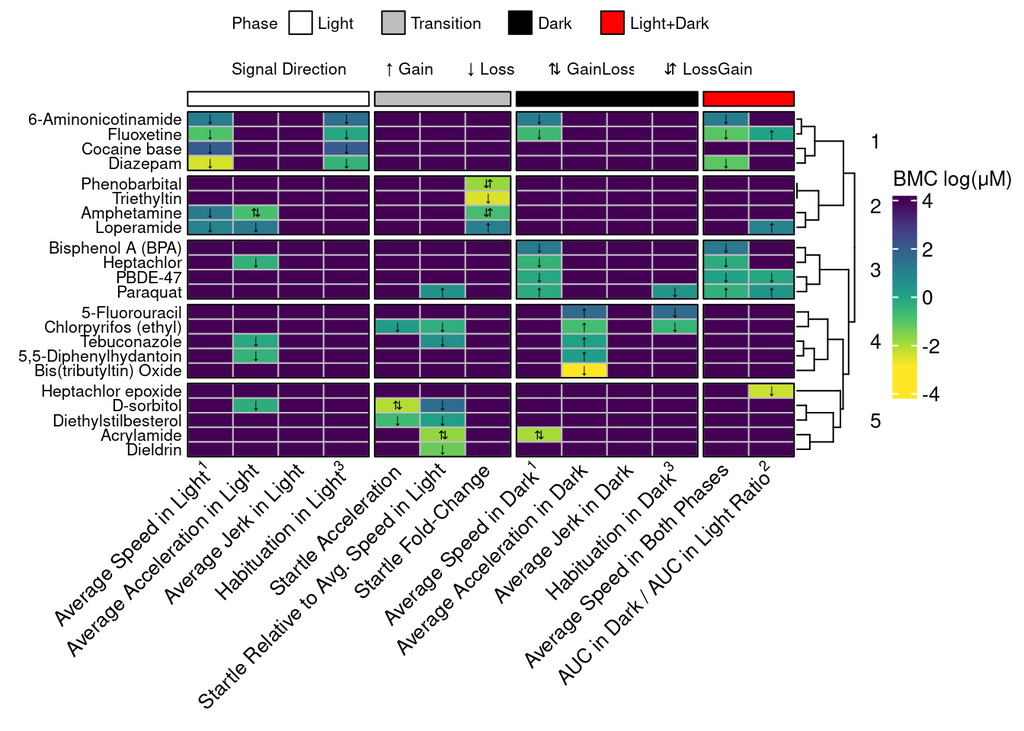

```r
# Create main heat map.
htlist <- ComplexHeatmap::Heatmap(bmd[actives,],

                        # Specify some parameters for heat legend.
                        name = paste0("BMC log(","\U03BC","M)"),
                        col = f2,
                        border_gp = grid::gpar(col="black",lwd=1),
                        rect_gp=grid::gpar(col="grey"),
                        show_heatmap_legend = TRUE,
                        heatmap_legend_param = list(legend_height = unit(3.5,"cm"),
                                                    direction = "vertical",
                                                    title_gp = grid::gpar(fontsize=10),
                                                    labels_gp = grid::gpar(fontsize=10)),

                        # Heatmap width and height
                        # width = unit(16,"in"),
                        # height = unit(18,"in"),

                        # Column label parameters
                        column_labels = col_labels, column_names_rot = 45,

                        # Split columns by phase.
                        column_split = factor(c(rep("Light",4), rep("Transition",3),rep("Dark",4),rep("Light+Dark",2)),
                                              levels=c("Light","Transition","Dark","Light+Dark")),

                        # Specify some column parameters.
                        column_title = NULL,
                        top_annotation = column_ha,

                        # Add signal direction arrows.
                        cell_fun = cell_fun,

                        # Specify some parameters row dendrogram aesthetics and row labels.
                        row_title_side = "right",
                        row_title_rot = 0,
                        row_split = 5,
                        row_dend_side = "right",
                        row_names_side = "left",

                        # Clustering parameters.
                        cluster_columns = FALSE,
                        cluster_rows = TRUE,
                        clustering_distance_rows = "pearson",

                        # Font sizes
                        row_names_gp = grid::gpar(fontsize=8),
                        column_names_gp = grid::gpar(fontsize=10),
                        row_title_gp = grid::gpar(fontsize=10),
                        column_title_gp = grid::gpar(fontsize=10)
                        )
draw(htlist, merge_legend = FALSE, annotation_legend_list = lgd_list,
     annotation_legend_side = "top", align_annotation_legend = "heatmap_center")
```

### Where were chemicals active?

Net activity endpoints (avgS_L , avgS_D, or avgS_T).

```r
tcpl_out.dt[endp%in%c("avgS_L","avgS_D","avgS_T") & hitcall>0.8, unique(name)]
```

```
##  [1] "Polybrominated diphenyl ether (PBDE)-47"
##  [2] "6-Aminonicotinamide"
##  [3] "Bisphenol A (BPA)"
##  [4] "Acrylamide"
##  [5] "Fluoxetine"
##  [6] "Amphetamine"
##  [7] "Paraquat"
##  [8] "Cocaine base"
##  [9] "Diazepam"
## [10] "Heptachlor"
## [11] "Loperamide"
```

Rate of change of activity.

```r
tcpl_out.dt[endp%in%c("avgA_L","avgA_D") & hitcall>0.8, unique(name)]
```

```
## [1] "5,5-Diphenylhydantoin"  "Chlorpyrifos (ethyl)"   "D-sorbitol"
## [4] "Tebuconazole"           "5-Fluorouracil"         "Amphetamine"
## [7] "Bis(tributyltin) Oxide" "Heptachlor"             "Loperamide"
```

Range of activity.

```r
tcpl_out.dt[endp%in%c("hbt_L","hbt_D") & hitcall>0.8, unique(name)]
```

```
## [1] "Chlorpyrifos (ethyl)" "5-Fluorouracil"       "6-Aminonicotinamide"
## [4] "Fluoxetine"           "Paraquat"             "Cocaine base"
## [7] "Diazepam"
```

Zebrafish startle.

```r
tcpl_out.dt[endp%in%c("strtlA","strtlAavg","strtlF") & hitcall>0.8, unique(name)]
```

```
##  [1] "Chlorpyrifos (ethyl)" "D-sorbitol"           "Tebuconazole"
##  [4] "Acrylamide"           "Phenobarbital"        "Amphetamine"
##  [7] "Paraquat"             "Diethylstilbesterol"  "Dieldrin"
## [10] "Loperamide"           "Triethyltin"
```

### Activity per Endpoint

Number of chemicals active per endpoint.

```r
tcpl_out.dt[hitcall > 0.8, .("no. of chms active"=.N), by = endp]
```

```
##          endp no. of chms active
##  1:    avgA_L                  6
##  2:    avgA_D                  5
##  3:    strtlA                  3
##  4: strtlAavg                  7
##  5:     hbt_D                  3
##  6:    avgS_D                  7
##  7:    avgS_T                  7
##  8:     AUC_r                  5
##  9:    avgS_L                  6
## 10:     hbt_L                  4
## 11:    strtlF                  4
```

Most sensitive endpoint.

```r
tcpl_out.dt[hitcall > 0.8, .("no. of chms active"=.N), by = endp][which(`no. of chms active`==max(`no. of chms active`))]
```

```
##         endp no. of chms active
## 1: strtlAavg                  7
## 2:    avgS_D                  7
## 3:    avgS_T                  7
```

Do chemicals active in avgS_T completely overlap with those active in avgS_D?

```r
identical(tcpl_out.dt[endp=="avgS_D" & hitcall>0.8, unique(name)],
          tcpl_out.dt[endp=="avgS_T" & hitcall>0.8, unique(name)])
```

```
## [1] FALSE
```

Acrylamide is active in avgS_D but not avgS_T. Diazepam is active in avgS_T but not avgS_D. So sets are nearly identical implying avgS_D is highly correlated with avgS_T. Diazepam was found active in avgS_L. Since chemicals active in avgS_T were active in either avgS_D or avgS_L this endpoint might be reduntant. Activity in avgS_T could be an indication that avgS_L or avgS_D changed alot, but it was not capable in this dataset to detect changes independently of other avgS endpoints.

Evaluate if avgS_T can be used as an indicator of intense respose in one endpoint or the other.

Of the endpoints that we construct how many hits are we seeing.

```r
cnstrct_endpoints <- c("avgA_L", "avgJ_L", "hbt_L", "strtlA", "strtlAavg", "strtlF", "avgA_D", "avgJ_D", "hbt_D", "AUC_r")
tcpl_out.dt[hitcall > 0.8, .("no. of chms active"=.N), by = endp][endp %in% c(cnstrct_endpoints)]
```

```
##         endp no. of chms active
## 1:    avgA_L                  6
## 2:    avgA_D                  5
## 3:    strtlA                  3
## 4: strtlAavg                  7
## 5:     hbt_D                  3
## 6:     AUC_r                  5
## 7:     hbt_L                  4
## 8:    strtlF                  4
```

Startle acceleration vs. average is the most sensitive. So we are observing changes in zebrafish startle intensity.

### Noise related to endpoints

Evaluation of CV We don’t see an association of endpoint sensitivity with endpoint noise - We can mention this or simply state that there aren’t enough active chemicals to make this evaluation

### What does the number of endpoints a chemical is active in say about the activity of an endpoint

Is it more clear that behavioral profiles are perturbed when many endpoints are active - of the chemicals found active in many endpoints are these chemicals substantiated as LMR actives by other laboratories?

### Potency Estimates for Chemicals

Which chemical has the lowest potency estimate? Which chemicals have the lowest median potency estimate?

Order chemicals by their lowest BMC.

```r
minBMCs <- apply(bmd, 1, min, na.rm=TRUE)
minBMCs.1 <- minBMCs[minBMCs < 4]
minBMCs.2 <- 10^(minBMCs.1[order(minBMCs.1)])

minBMCs.2
```

```
## Bis(tributyltin) Oxide            Triethyltin               Diazepam
##           1.283886e-03           2.844639e-03           3.200217e-03
##     Heptachlor epoxide             D-sorbitol             Acrylamide
##           4.167956e-03           7.582866e-03           1.025279e-02
##          Phenobarbital               Dieldrin             Fluoxetine
##           1.439967e-02           5.023196e-02           8.314514e-02
##            Amphetamine   Chlorpyrifos (ethyl)    Diethylstilbesterol
##           1.408229e-01           1.602418e-01           2.061827e-01
##             Heptachlor  5,5-Diphenylhydantoin               Paraquat
##           3.386513e-01           3.541023e-01           4.058908e-01
##                PBDE-47           Tebuconazole             Loperamide
##           7.218267e-01           7.521895e-01           8.997297e+00
##    6-Aminonicotinamide      Bisphenol A (BPA)         5-Fluorouracil
##           1.240090e+01           1.514506e+01           4.053289e+01
##           Cocaine base
##           1.055481e+02
```

```r
which( minBMCs == min(minBMCs) )
```

```
## Bis(tributyltin) Oxide
##                     22
```

Bis(tributyltin) Oxide is found to be the most potent chemical.

Which chemical is most potent when looking at the median of it’s active endpoints? Will likely be Bis(tributyltin) Oxide, but observe how ordering changes.

```r
select <- apply(bmd, 1, function(row) any(row<4))
med_BMC <- bmd[select,]
med_BMC[med_BMC==4] <- NA

med_BMC.1 <- apply(med_BMC, 1, median, na.rm=TRUE)
med_BMC.2 <- 10^(med_BMC.1[order(med_BMC.1)])

data.table("Order by Minimum BMC" = names(minBMCs.2), "Order by Median BMC" = names(med_BMC.2))
```

```
##       Order by Minimum BMC    Order by Median BMC
##  1: Bis(tributyltin) Oxide Bis(tributyltin) Oxide
##  2:            Triethyltin            Triethyltin
##  3:               Diazepam     Heptachlor epoxide
##  4:     Heptachlor epoxide             Acrylamide
##  5:             D-sorbitol          Phenobarbital
##  6:             Acrylamide               Dieldrin
##  7:          Phenobarbital               Diazepam
##  8:               Dieldrin            Amphetamine
##  9:             Fluoxetine             Fluoxetine
## 10:            Amphetamine   Chlorpyrifos (ethyl)
## 11:   Chlorpyrifos (ethyl)             Heptachlor
## 12:    Diethylstilbesterol    Diethylstilbesterol
## 13:             Heptachlor             D-sorbitol
## 14:  5,5-Diphenylhydantoin  5,5-Diphenylhydantoin
## 15:               Paraquat                PBDE-47
## 16:                PBDE-47           Tebuconazole
## 17:           Tebuconazole               Paraquat
## 18:             Loperamide             Loperamide
## 19:    6-Aminonicotinamide    6-Aminonicotinamide
## 20:      Bisphenol A (BPA)      Bisphenol A (BPA)
## 21:         5-Fluorouracil         5-Fluorouracil
## 22:           Cocaine base           Cocaine base
##       Order by Minimum BMC    Order by Median BMC
```

Some chemicals positions by highest to lowest potency decrease a lot when median BMC is considered rather than minimum BMC. D-Sorbitol is a noticeable example. For all chemicals evaluate their range of BMC potency metrics. Can we associate a large range of BMCs with spurious activity?

```r
range_BMC <- bmd[select,]
range_BMC[range_BMC==4] <- NA
select1 <- apply(range_BMC, 1, function(row) sum(is.na(row)) < 12)
range_BMC1 <- range_BMC[select1,]
range_BMC2 <- apply(range_BMC1, 1, range, na.rm=TRUE)
range_BMC3 <- range_BMC2[2,] - range_BMC2[1,]

BMCrange <- data.table("cpid" = names(range_BMC3[order(range_BMC3)]), "BMCrange" = range_BMC3[order(range_BMC3)])
DT::datatable(BMCrange)
```

|  | cpid | BMCrange |
| --- | --- | --- |
| 1 | 5-Fluorouracil | 0.0244242848813085 |
| 2 | Bisphenol A (BPA) | 0.0328351801939524 |
| 3 | Cocaine base | 0.0329757828912309 |
| 4 | PBDE-47 | 0.162295821433382 |
| 5 | Heptachlor | 0.178491564718462 |
| 6 | Acrylamide | 0.237034198102348 |
| 7 | Loperamide | 0.244624674183483 |
| 8 | 6-Aminonicotinamide | 0.434135807504275 |
| 9 | 5,5-Diphenylhydantoin | 0.596708717287905 |
| 10 | Tebuconazole | 0.689603365995509 |

[output cut: 7 more lines]

D-sorbitol stands out as having an extreme range of BMC potency estimates. Before we have tried to label D-sorbitol’s extreme range of activity as an indication of D-sorbitol’s spuriousness. The chemical with the second largest range is Amphetamine, which interestingly enough was the chemical whose concentration response data displayed the poorly modeled gain-loss behavior. What about Diazepam?

```r
chemical <- "Diazepam"

# Units
unit.t = "min"
unit.mov = "cm"
unit.conc = paste0("\U03BC","M")
prsp = "SA"
no.A = 10

# Extract chemical data
group <- unique(data[cpid == chemical, egid])

## Identify movement columns of interest
t.cols <- grep("vt", names(data), value = TRUE)
cols <- t.cols[(no.A+1):length(t.cols)]
A.cols <- t.cols[!(t.cols%in%cols)]

## extract data to be plotted, exclude acclimation
to.fit <- data[cpid==chemical | (wllt=="v" & egid==group), -A.cols, with=FALSE]

# create appropriate axes titles for plots
label.y <- "Speed"

# Format data for plotting

## calculate mean and 50% CIs for each vector column by concentration group, excluding concentration
exclude.A <- t.cols[!(t.cols%in%A.cols)]
means <- to.fit[, lapply(.SD, function(col) mean(col,na.rm=T)),
                .SDcols = exclude.A,
                by = conc]

## calculate CI's for transformed values then transform back
shift <- 1
logCIs <- to.fit[, lapply(.SD, function(x) log10(x+shift)), .SDcols=exclude.A, by=conc][
  , lapply(.SD, function(x) t.test(x,conf.level=0.50)$conf.int), .SDcols=exclude.A, by=conc]
CIs <- logCIs[, lapply(.SD, function(x) (10^x)-shift), by=conc][,lapply(.SD, function(col) abs(diff(col))/2), .SDcols=exclude.A, by=conc]

## elongate means and CIs data, and join
means_long <- data.table::melt(means, id.vars = "conc", variable.name = "t", value.name = "mean")
means_long[, t := sub("vt","",t)]
CIs_long <- data.table::melt(CIs, id.vars = "conc", variable.name = "t", value.name = "CI")
CIs_long[, t := sub("vt","",t)]
stats <- means_long[CIs_long, on = c("conc","t")][, conc := as.factor(conc)]
stats[, t := as.numeric(t)]

# create standard error of mean estimates by time period and plot as ribbons or error bars

# plot time-series data

## create title, x- and y-axis titles, legend labels, and legend title
title <- paste0("Sample Averaged Time-Series for ", chemical)
title.t <- paste0("Time (",unit.t,")")
title.mean <- paste0("Mean ", label.y, " (",unit.mov,"/",unit.t,")")
conc.n <- to.fit[wllq==1, .N, by=.(conc)][order(conc)]
legend.labels <- paste0(conc.n$conc, ", n=", conc.n$N)

title.legend <- paste0("Concentration (", unit.conc, ")")

## get better colors for plotting
N <- length(unique(to.fit[,conc]))
colors <- viridis::viridis(N)

## create x-axis breaks and labels
m <- as.integer(max(means_long[,t]))
x.breaks <- seq(from=no.A,to=m,by=10)
x.labels1 <- 2*seq(from=no.A,to=m,by=10)
x.labels2 <- x.labels1 - 2
x.labels <- paste(x.labels2, x.labels1, sep="-")

## plot
SAplot_Dzp <- ggplot() +
          geom_point(data = stats, aes(x=t, y=mean, color=as.factor(conc))) +
          geom_line(data = stats, aes(x=t, y=mean, color=conc, group=conc)) +
          scale_x_continuous(breaks = x.breaks, labels = x.labels) +
          scale_color_manual(values = colors, labels=legend.labels) +
          geom_ribbon(data = stats,
                      aes(x=t, ymax=mean+CI, ymin=mean-CI, group=conc, fill=conc),
                      alpha = 0.25) +
          geom_rect(aes(xmin=10,xmax=30,ymin=-1.25,ymax=-0.5) ,fill="white", color="black") +
          geom_rect(aes(xmin=30,xmax=50,ymin=-1.25,ymax=-0.5) ,fill="black", color="black") +
          annotate("text", x=c(20,40), y=rep(-0.875,2), color=c("black","white"), label=c("Light Phase","Dark Phase"), size=5) +
          scale_fill_manual(values = colors, labels=legend.labels) +
          labs(title = title, subtitle = "Acclimation Period Excluded: 50% Confidence Bands",
               x = title.t, y = title.mean, color = title.legend) +
          guides(fill = "none") +
          theme_bw() +
          theme(text = element_text(size = 18))
```

```r
row1_Dzp <- rows_n[[chemical]][["avgS_L"]]
row2_Dzp <- rows_n[[chemical]][["hbt_L"]]
row3_Dzp <- rows_n[[chemical]][["avgS_T"]]

fit1_Dzp <- concRespCoreZR(row1_Dzp, do.plot = TRUE, verbose.plot = FALSE)[["plot"]]
fit2_Dzp <- concRespCoreZR(row2_Dzp, do.plot = TRUE, verbose.plot = FALSE)[["plot"]]
fit3_Dzp <- concRespCoreZR(row3_Dzp, do.plot = TRUE, verbose.plot = FALSE)[["plot"]]

# fit1_CPF$theme$text$size = 4
# fit2_CPF$theme$text$size = 4
#
# fit1_CPF$heme$line$size = 0.15
```

```r
# grobs <- list(SAplot_CPF, fit1_CPF, fit2_CPF)
# layout <- matrix(c(1,1,1,1,2,3), nrow=3, ncol=2, byrow=TRUE)
#
# gridExtra::grid.arrange(grobs = grobs, layout_matrix = layout)
```

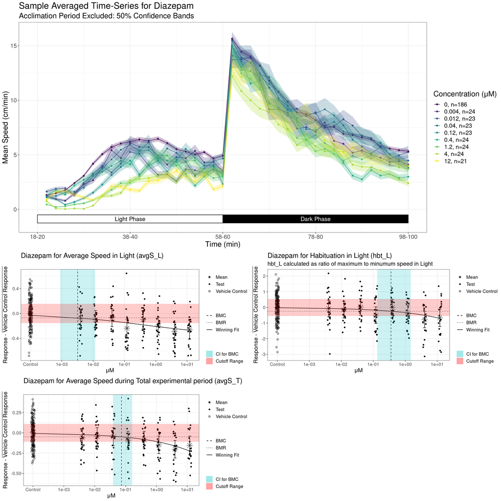

```r
p1 <- cowplot::plot_grid(fit1_Dzp, fit2_Dzp, fit3_Dzp, nrow=2)
cowplot::plot_grid(SAplot_Dzp, p1, nrow=2)
```

For Diazepam we can see that the curve-fitting procedure may be erroneously producing low estimates for BMC. This erroneous detection is indicated by the consistency of activity levels in low-concentration treatment groups. This seems to imply that baseline activity levels for Diazepam treated groups and control were different. At high concentration more typical concentration reponse behavior is observed.

So it seems that the range of BMC estimates can be used to assess if any issues are occuring in the curve-fitting procedure that can be due to curve-fitting inadequacy, spurious activity, or baseline-shift from control to treatment.

Do we see that BMC estimates associated with any particular endpoint tend to be lower than others?

```r
active_BMC <- bmd[select,]
active_BMC[med_BMC==4] <- NA
```